# Harry Potter and the Art of Fanfiction

Isabel Leiva

April 2026

# Research Question

It is often said that fanfiction is “darker” thematically compared to the original works they are based off of. Some even go as far as to say that these more explicit themes is what makes the fanfiction themselves original works. However, this begs the question of whether fanfiction is “darker” than the original works in some tangible way. Thankfully, with the advent of natural language processing and semantic analysis, we can finally answer this afe old question:

Does fanfiction differ significantly in overall negative valence and negative valence over time from the works that it draws from?

We will be testing this using one of the most popular fandoms of the 21st century, Harry Potter.

# Data Preperation

All of the original texts are available in [Bradley Boemke’s ‘harrypotter’ package](https://github.com/bradleyboehmke/harrypotterpackage).

Note: there are two ‘harrypotter’ packages. To snag the correct one, use code snippet: devtools::install_github(“bradleyboehmke/harrypotter”)

All of the Fanfiction is available on Archive of our own [https://archiveofourown.org/]

## Original Harry Potter Cleanup

```r
#downloading the harry potter novels from the package
#devtools::install_github("bradleyboehmke/harrypotter")
data(package = "harrypotter")
data(philosophers_stone)
data(chamber_of_secrets)
data(prisoner_of_azkaban)
data(goblet_of_fire)
data(order_of_the_phoenix)
data(half_blood_prince)
data(deathly_hallows)

#collapsing the novels into one column and row
p <- philosophers_stone %>% #write to an object
  paste(collapse= " ") #collapse character vector
c <- chamber_of_secrets %>% #write to an object
  paste(collapse= " ") #collapse character vector
a <- prisoner_of_azkaban %>% #write to an object
  paste(collapse= " ") #collapse character vector
g <- goblet_of_fire %>% #write to an object
  paste(collapse= " ") #collapse character vector
o <- order_of_the_phoenix %>% #write to an object
  paste(collapse= " ") #collapse character vector
h <- half_blood_prince %>% #write to an object
  paste(collapse= " ") #collapse character vector
d <- deathly_hallows %>% #write to an object
  paste(collapse= " ") #collapse character vector

#creating dataframe with books text
hp_og <- data.frame(text = rbind(p, c, a, g, o, h, d))

#creating new author, genre, & doc_id
hp_og <- hp_og %>%
  mutate(author = c(1, 1, 1, 1, 1, 1, 1),
         genre = c("og", "og", "og", "og", "og", "og", "og"),
         doc_id = c("philosophers_stone", "chamber_of_secrets", "prisoner_of_azkaban", "goblet_of_fire", "order_of_the_phoenix", "half_blood_prince", "deathly_hallows"))
```

## Harry Potter Fanfic Cleanup

```r
#creating a df with all IDs
#Directory containing CSV files
fic_directory <- "fanfics"

#List of .txt files in the directory
txt_files <- list.files(path = fic_directory, pattern = "*.txt", full.names = TRUE)

#reading in text files as dataframes
dataframes <- lapply(txt_files, readtext)

# rbind all dataframes
hp_fanfic <- do.call(rbind, dataframes)

#creating author column
hp_fanfic$author <- c(2, 3, 4, 5, 6, 7, 8, 9, 10, 11, 12, 13, 8, 14, 15, 16, 17, 18, 19, 20) #choices and kill your darlings have the same author

#creating genre column
hp_fanfic$genre <- c("fanfic", "fanfic", "fanfic", "fanfic", "fanfic", "fanfic", "fanfic", "fanfic", "fanfic", "fanfic", "fanfic", "fanfic", "fanfic", "fanfic", "fanfic", "fanfic", "fanfic", "fanfic", "fanfic", "fanfic")
```

## Joining Dataframes

```r
all_hp <- rbind(hp_og, hp_fanfic)
all_hp <- all_hp %>% dplyr::select(doc_id, genre, author, text)
rownames(all_hp) <- NULL

#making the following variables factors
all_hp$doc_id <- as.factor(all_hp$doc_id)
all_hp$genre <-  as.factor(all_hp$genre)
all_hp$author <-  as.factor(all_hp$author)

#confirming variables are now factors
str(all_hp$doc_id)
```

```
##  Factor w/ 27 levels "A_Marauders_Plan.txt",..: 22 7 23 13 21 14 9 1 2 3 ...
```

```r
str(all_hp$genre)
```

```
##  Factor w/ 2 levels "fanfic","og": 2 2 2 2 2 2 2 1 1 1 ...
```

```r
str(all_hp$author)
```

```
##  Factor w/ 20 levels "1","2","3","4",..: 1 1 1 1 1 1 1 2 3 4 ...
```

## Loading & cleaning sentiment database

```r
load(url("https://github.com/Reilly-ConceptsCognitionLab/reillylab_publicdata/blob/main/lookup_Jul25.rda?raw=true"))
lookup_db <- lookup_Jul25 #renaming dataframe
colnames(lookup_db)
```

```
##  [1] "word"                    "emo_anger"
##  [3] "emo_anger_rescale"       "emo_anxiety"
##  [5] "emo_anxiety_rescale"     "emo_arousal_b24"
##  [7] "emo_arousal_b24_rescale" "emo_boredom"
##  [9] "emo_boredom_rescale"     "emo_confusion"
## [11] "emo_confusion_rescale"   "emo_excitement"
## [13] "emo_excitement_rescale"  "emo_guilt"
## [15] "emo_guilt_rescale"       "emo_happiness"
## [17] "emo_happiness_rescale"   "emo_intensity"
## [19] "emo_intensity_recale"    "emo_sadness"
## [21] "emo_sadness_rescale"     "emo_trust"
## [23] "emo_trust_rescale"       "emo_valence_b24"
## [25] "emo_valence_b24_rescale" "lex_AoA"
## [27] "lex_AoA_rescale"         "lex_freqlg10"
## [29] "lex_freqlg10_rescale"    "lex_n_morphemes"
## [31] "lex_n_senses"            "lex_n_senses_rescale"
## [33] "phon_n_lett"             "phon_nsyll"
## [35] "sem_auditory"            "sem_auditory_rescale"
## [37] "sem_cnc_b24"             "sem_cnc_b24_rescale"
## [39] "sem_cnc_v2013"           "sem_cnc_v2013_rescale"
## [41] "sem_diversity"           "sem_diversity_rescale"
## [43] "sem_neighbors"           "sem_neighbors_rescale"
## [45] "sem_visual"              "sem_visual_rescale"
```

```r
lookup_small <- lookup_db %>% dplyr::select(word, emo_valence_b24_rescale,emo_sadness_rescale) #creating database that suites hypotheses being tested
lookup_small[1:20,] #printing the first 20 lines of the df
```

| word | emo_valence_b24_rescale | emo_sadness_rescale |
| --- | --- | --- |
| a | 4.51 | 2.37 |
| aa | 4.49 | 1.99 |
| aaa | NA | 1.66 |
| aaaa | NA | 1.73 |
| aaaaa | NA | 1.95 |
| aaaaaaaaah | NA | 2.41 |
| aaaaaaaah | NA | 2.28 |
| aaaaaaah | 4.60 | 2.27 |
| aaaaaah | NA | 2.14 |
| aaaaah | NA | 2.37 |
| aaaaahhh | NA | 2.12 |
| aaaaahhhh | NA | 2.56 |
| aaaaahhhhh | NA | 2.61 |
| aaaaargh | NA | 2.22 |
| aaaagh | NA | 2.52 |
| aaaah | 5.57 | 2.48 |
| aaaahh | NA | 2.25 |
| aaaahhh | NA | 1.88 |
| aaaahhhh | NA | 2.40 |
| aaaargh | NA | 2.67 |

```r
lookup_small[lookup_small$word == "smile",] #checking directionality
```

|  | word | emo_valence_b24_rescale | emo_sadness_rescale |
| --- | --- | --- | --- |
| 62497 | smile | 8.34 | 0.75 |

```r
lookup_small[lookup_small$word == "cry",] #checking directionality
```

|  | word | emo_valence_b24_rescale | emo_sadness_rescale |
| --- | --- | --- | --- |
| 15698 | cry | 1.86 | 5.04 |

## Cleaning genie

```r
cleaning_genie <- function(dat, wordcol, omit_stops = TRUE, lemmatize = TRUE) {
  # Input validation
  #telling R what column in your dataframe is the text in quotes 'wordcol', this error message checks
  if (!wordcol %in% names(dat)) {
    stop(paste("Column", wordcol, "not found in dataframe"))
  }
#load stopword and replacement lists from github
load(url("https://github.com/Reilly-ConceptsCognitionLab/reillylab_publicdata/blob/main/Temple_stops25.rda?raw=true"))
load(url("https://github.com/Reilly-ConceptsCognitionLab/reillylab_publicdata/blob/main/replacements_25.rda?raw=true"))

# Creating a working df and standardizing
  dat_prep <- dat %>% #creating a working df called "dat prep"
    dplyr::mutate(id_row_orig = factor(seq_len(nrow(dat))), # creating a new row that tracks id number (starting from 1)
      text_initialsplit = tryCatch(stringi::stri_enc_toutf8(as.character(.[[wordcol]]), #creating new row that standardizes text as UTF8
                                 is_unknown_8bit = TRUE,
                                 validate = TRUE), error = function(e) stringi::stri_encode(as.character(.[[wordcol]]), to = "UTF-8")
      ) %>% tolower()) #makes all text lower case

  # Standardize apostrophes in original text
  dat_prep <- dat_prep %>% dplyr::mutate(text_initialsplit = ifelse(
        is.na(text_initialsplit), NA_character_, stringi::stri_replace_all_regex(
          text_initialsplit,
          "[\u2018\u2019\u02BC\u201B\uFF07\u0092\u0091\u0060\u00B4\u2032\u2035]",
          "'"
        )
      )
    )

  # Perform initial split into words (retains contractions)
  dat_prep <- dat_prep %>% tidyr::separate_rows(text_initialsplit, sep = "[[:space:]]+") %>%
    dplyr::mutate(
      text_initialsplit = ifelse(
        is.na(text_initialsplit) | stringi::stri_isempty(text_initialsplit),
        NA_character_,
        text_initialsplit
      )
    ) %>%
    # Remove original column
    dplyr::select(-all_of(wordcol))

  # Creating clean column (called "word_clean") with actual cleaned text
  dat_prep <- dat_prep %>%
    dplyr::mutate(
      word_clean = text_initialsplit,
      # Remove non-alphabetic characters except apostrophes
      word_clean = ifelse(
        is.na(word_clean),
        NA_character_,
        stringi::stri_replace_all_regex(word_clean, "[^a-zA-Z']", " ")
      ),
      # Remove whitespace
      word_clean = ifelse(
        is.na(word_clean),
        NA_character_,
        stringr::str_squish(word_clean)
      ),
      word_clean = ifelse(
        is.na(word_clean),
        NA_character_,
        stringi::stri_replace_all_regex(word_clean, "[^a-z']", "")
      ),
      word_clean = ifelse(
        is.na(word_clean),
        NA_character_,
        stringi::stri_replace_all_regex(word_clean, "[^[:alnum:]']", "")
      )
    )

#Replace words function - this finds contractions and replaces them with their expanded forms from a lookup database.
 replace_words <- function(word_clean, replacement_df) {
 for (i in seq_len(nrow(replacement_df))) {
   text_vector <- gsub(
     pattern = replacement_df$word[i],
     replacement = replacement_df$replacement[i],
     x = word_clean, ignore.case = TRUE)
 }
 return(word_clean)
 }

 #run replace words function on dat_prep
dat_prep <- replace_words(dat_prep, replacement_df = replacements_25)

  # Perform additional splitting after replacements (keeping NAs)
  dat_prep <- dat_prep %>%
    tidyr::separate_rows(word_clean, sep = "[[:space:]]+", convert = TRUE) %>%
    dplyr::mutate(
      word_clean = ifelse(
        is.na(word_clean) | stringi::stri_isempty(word_clean),
        NA_character_,
        word_clean
      ),
      id_row_postsplit = seq_len(dplyr::n())
    )

  # Lemmatization if requested (only for non-NA values)
  if (lemmatize) {
    dat_prep <- dat_prep %>%
      dplyr::mutate(
        word_clean = ifelse(
          is.na(word_clean),
          NA_character_,
          textstem::lemmatize_strings(word_clean)
        )
      )
  }

  # Stopword removal if requested (now keeps NAs)
  if (omit_stops) {
    stopwords <- tolower(Temple_stops25$word)
    dat_prep <- dat_prep %>%
      dplyr::mutate(
        is_stopword = ifelse(
          is.na(word_clean),
          NA,
          word_clean %in% stopwords
        ),
        word_clean = ifelse(is_stopword, NA_character_, word_clean)
      ) %>%
      dplyr::select(-is_stopword)  # Remove the is_stopword column
  }

  return(dat_prep)
}
```

## Deploy Genie

```r
hp_clean <- cleaning_genie(all_hp, 'text')

write.csv(hp_clean, file = "hp_clean.csv")
```

# Original Analysis

## Dataframe Setup (Valence)

```r
hp_clean <- read.csv("hp_clean.csv") #read in cleaned harry potter csv to save on cleaning time (took 24 hours!)

hp_analysis <- hp_clean %>%
  dplyr::left_join(lookup_small, by = c("word_clean" = "word")) %>% #joining gaslighting stories with the sentiment word ratings
  dplyr::select(doc_id, genre, author, word_clean, emo_valence_b24_rescale) %>% #selecting columns for analysis
  drop_na(emo_valence_b24_rescale) #dropping empty columns for analysis
hp_analysis[1:20,] #printing the first 20 lines of the df
```

| doc_id | genre | author | word_clean | emo_valence_b24_rescale |
| --- | --- | --- | --- | --- |
| philosophers_stone | og | 1 | boy | 5.23 |
| philosophers_stone | og | 1 | numb | 3.19 |
| philosophers_stone | og | 1 | privet | 4.57 |
| philosophers_stone | og | 1 | drive | 4.91 |
| philosophers_stone | og | 1 | proud | 7.89 |
| philosophers_stone | og | 1 | say | 4.53 |
| philosophers_stone | og | 1 | perfectly | 7.14 |
| philosophers_stone | og | 1 | normal | 4.56 |
| philosophers_stone | og | 1 | thank | 7.06 |
| philosophers_stone | og | 1 | very | 4.53 |
| philosophers_stone | og | 1 | much | 4.52 |
| philosophers_stone | og | 1 | last | 4.52 |
| philosophers_stone | og | 1 | people | 4.56 |
| philosophers_stone | og | 1 | expect | 4.64 |
| philosophers_stone | og | 1 | involve | 4.67 |
| philosophers_stone | og | 1 | strange | 4.47 |
| philosophers_stone | og | 1 | mysterious | 5.31 |
| philosophers_stone | og | 1 | just | 4.52 |
| philosophers_stone | og | 1 | hold | 4.52 |
| philosophers_stone | og | 1 | such | 4.52 |

```r
#creating a column to account for differing word counts
hp_analysis <- hp_analysis %>%
  group_by(doc_id) %>%
  mutate(time_point = seq_along(word_clean),
         word_count = n())
hp_analysis[38261:38262,] #printing to make sure its counting correctly
```

```
## # A tibble: 2 × 7
## # Groups:   doc_id [2]
##   doc_id    genre author word_clean emo_valence_b24_resc…¹ time_point word_count
##   <chr>     <chr>  <int> <chr>                       <dbl>      <int>      <int>
## 1 philosop… og         1 end                         4.42       38261      38261
## 2 chamber_… og         1 bad                         0.706          1      43325
## # ℹ abbreviated name: ¹emo_valence_b24_rescale
```

```r
hp_analysis[1:20,] #printing the first 20 lines of the df
```

```
## # A tibble: 20 × 7
## # Groups:   doc_id [1]
##    doc_id   genre author word_clean emo_valence_b24_resc…¹ time_point word_count
##    <chr>    <chr>  <int> <chr>                       <dbl>      <int>      <int>
##  1 philoso… og         1 boy                          5.23          1      38261
##  2 philoso… og         1 numb                         3.19          2      38261
##  3 philoso… og         1 privet                       4.57          3      38261
##  4 philoso… og         1 drive                        4.91          4      38261
##  5 philoso… og         1 proud                        7.89          5      38261
##  6 philoso… og         1 say                          4.53          6      38261
##  7 philoso… og         1 perfectly                    7.14          7      38261
##  8 philoso… og         1 normal                       4.56          8      38261
##  9 philoso… og         1 thank                        7.06          9      38261
## 10 philoso… og         1 very                         4.53         10      38261
## 11 philoso… og         1 much                         4.52         11      38261
## 12 philoso… og         1 last                         4.52         12      38261
## 13 philoso… og         1 people                       4.56         13      38261
## 14 philoso… og         1 expect                       4.64         14      38261
## 15 philoso… og         1 involve                      4.67         15      38261
## 16 philoso… og         1 strange                      4.47         16      38261
## 17 philoso… og         1 mysterious                   5.31         17      38261
## 18 philoso… og         1 just                         4.52         18      38261
## 19 philoso… og         1 hold                         4.52         19      38261
## 20 philoso… og         1 such                         4.52         20      38261
## # ℹ abbreviated name: ¹emo_valence_b24_rescale
```

```r
#making the following variables factors
hp_analysis$doc_id <- as.factor(hp_analysis$doc_id)
hp_analysis$genre <-  as.factor(hp_analysis$genre)
hp_analysis$author <-  as.factor(hp_analysis$author)

#quick summary stats
hp_val_summary <- hp_analysis %>% group_by(genre) %>% dplyr::summarize_at(c("emo_valence_b24_rescale"), list(mean=mean, sd=sd, min = min, max = max), na.rm=T) %>% ungroup() #grouping dataframe by gaslighting endorsement to summarize variables
print(hp_val_summary) #printing results
```

```
## # A tibble: 2 × 5
##   genre   mean    sd    min   max
##   <fct>  <dbl> <dbl>  <dbl> <dbl>
## 1 fanfic  4.74  1.26 0.0336     9
## 2 og      4.67  1.19 0.0336     9
```

```r
hp_count_summary <- hp_analysis %>% group_by(genre) %>% dplyr::summarize_at(c("word_count"), list(mean=mean, sd=sd, min = min, max = max), na.rm=T) %>% ungroup() #grouping dataframe by gaslighting endorsement to summarize variables
print(hp_count_summary) #printing results
```

```
## # A tibble: 2 × 5
##   genre     mean      sd   min    max
##   <fct>    <dbl>   <dbl> <int>  <int>
## 1 fanfic 313773. 126869. 91301 514840
## 2 og      90366.  30214. 38261 130468
```

## Overall Valence

Our first model proves to be null. There is no significant difference in valence between fanfiction and the originals, though it it important to note that in this graph that is plotting marginal effects already we can see a really large confidence interval for the original compared to the fanfiction ~foreshadowing for later~

```r
hp_val <- lmer(emo_valence_b24_rescale ~ genre + word_count + (1|author) + (1|doc_id), data = hp_analysis) #running lmers to test hypotheses
summary(hp_val) #printing results
```

```
## Linear mixed model fit by REML. t-tests use Satterthwaite's method [
## lmerModLmerTest]
## Formula: emo_valence_b24_rescale ~ genre + word_count + (1 | author) +
##     (1 | doc_id)
##    Data: hp_analysis
##
## REML criterion at convergence: 18175190
##
## Scaled residuals:
##     Min      1Q  Median      3Q     Max
## -3.8164 -0.2176 -0.1477 -0.0008  3.5428
##
## Random effects:
##  Groups   Name        Variance  Std.Dev.
##  doc_id   (Intercept) 0.0006001 0.0245
##  author   (Intercept) 0.0055800 0.0747
##  Residual             1.5723266 1.2539
## Number of obs: 5523586, groups:  doc_id, 27; author, 20
##
## Fixed effects:
##               Estimate Std. Error         df t value Pr(>|t|)
## (Intercept)  4.737e+00  3.219e-02  2.361e+01 147.163   <2e-16 ***
## genreog     -5.980e-02  7.955e-02  1.327e+01  -0.752    0.465
## word_count  -5.546e-09  1.074e-07  1.923e+01  -0.052    0.959
## ---
## Signif. codes:  0 '***' 0.001 '**' 0.01 '*' 0.05 '.' 0.1 ' ' 1
##
## Correlation of Fixed Effects:
##            (Intr) genreg
## genreog    -0.317
## word_count -0.829  0.230
## fit warnings:
## Some predictor variables are on very different scales: consider rescaling.
## You may also use (g)lmerControl(autoscale = TRUE) to improve numerical stability.
```

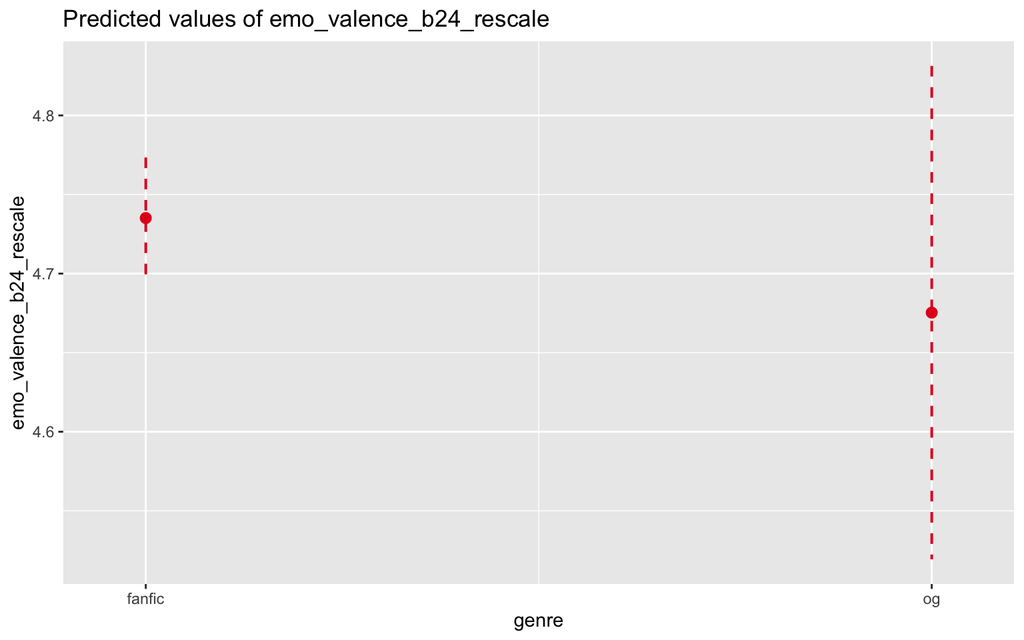

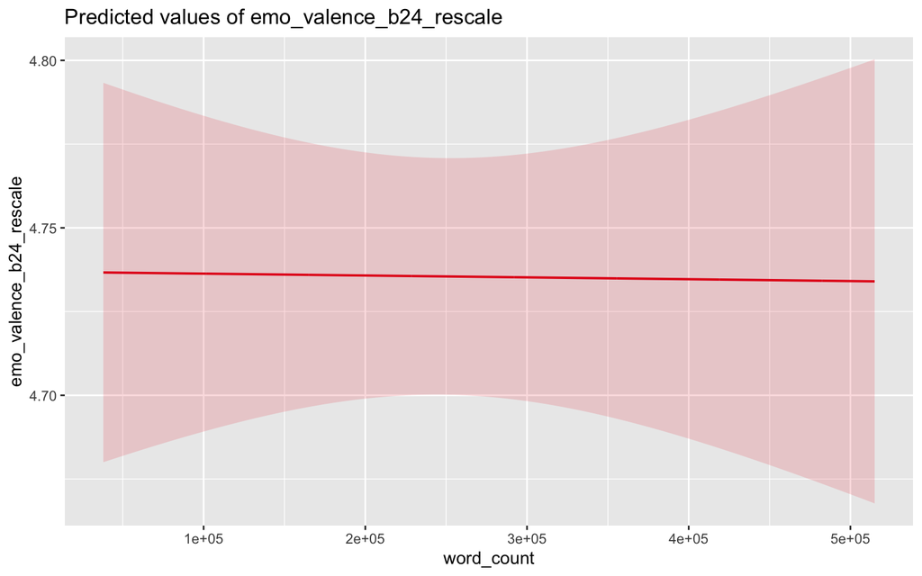

```r
#vizualize
plot_model(hp_val, type = "pred")
```

## Valence Over Time

Now here is where things get interesting. When accounting for time point in the story, with 1 representing the first word in the piece we can see that there is a significant interaction between genre and time point on valence. In a shocking turn of events though, it appears that the original works are driving this interaction rather than the fanfiction. I went ahead and dug into this by sub-setting the data

```r
hp_time_val <- lmer(emo_valence_b24_rescale ~ time_point*genre + word_count + (1|author) + (1|doc_id), data = hp_analysis) #running lmers to test hypotheses
summary(hp_time_val) #printing results
```

```
## Linear mixed model fit by REML. t-tests use Satterthwaite's method [
## lmerModLmerTest]
## Formula: emo_valence_b24_rescale ~ time_point * genre + word_count + (1 |
##     author) + (1 | doc_id)
##    Data: hp_analysis
##
## REML criterion at convergence: 18175000
##
## Scaled residuals:
##     Min      1Q  Median      3Q     Max
## -3.8264 -0.2165 -0.1490 -0.0009  3.5478
##
## Random effects:
##  Groups   Name        Variance  Std.Dev.
##  doc_id   (Intercept) 0.0005036 0.02244
##  author   (Intercept) 0.0055014 0.07417
##  Residual             1.5722542 1.25390
## Number of obs: 5523586, groups:  doc_id, 27; author, 20
##
## Fixed effects:
##                      Estimate Std. Error         df t value Pr(>|t|)
## (Intercept)         4.730e+00  3.107e-02  2.351e+01 152.235   <2e-16 ***
## time_point         -6.529e-08  5.750e-09  5.485e+06 -11.353   <2e-16 ***
## genreog            -3.019e-02  7.878e-02  1.428e+01  -0.383    0.707
## word_count          5.568e-08  1.026e-07  1.882e+01   0.543    0.594
## time_point:genreog -6.344e-07  6.179e-08  5.429e+04 -10.267   <2e-16 ***
## ---
## Signif. codes:  0 '***' 0.001 '**' 0.01 '*' 0.05 '.' 0.1 ' ' 1
##
## Correlation of Fixed Effects:
##             (Intr) tm_pnt genreg wrd_cn
## time_point  -0.003
## genreog     -0.312  0.004
## word_count  -0.820 -0.024  0.223
## tm_pnt:gnrg  0.034 -0.092 -0.040 -0.039
## fit warnings:
## Some predictor variables are on very different scales: consider rescaling.
## You may also use (g)lmerControl(autoscale = TRUE) to improve numerical stability.
```

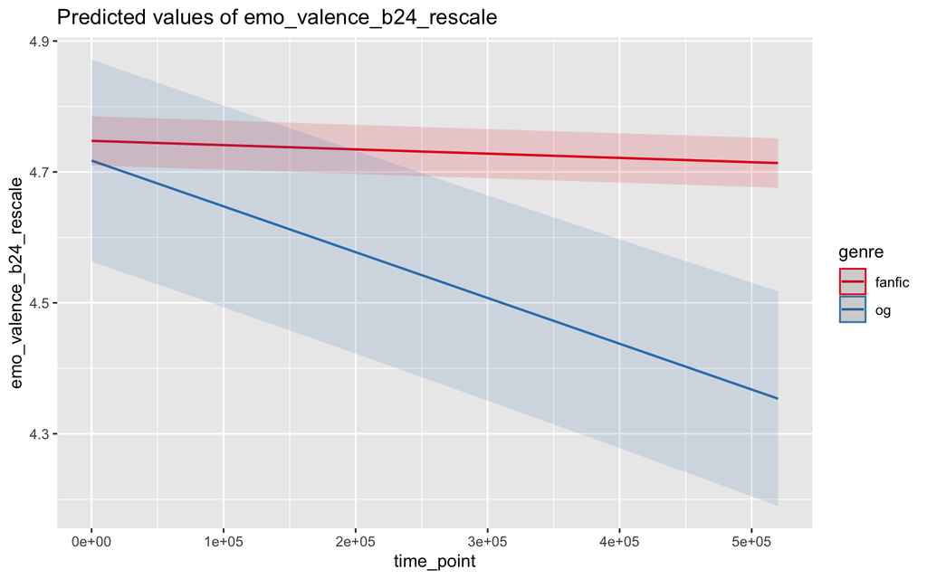

```r
# visualize
plot_model(hp_time_val, type = "int")
```

## Valence Over Time (Subset)

We can see that in the original series all of the books trend more negative over time, with the first 3 books having the most dramatic change in valence. The fanfiction on the other hand seems to vary a bit more wildly in valence within group. Most importantly, the fanfictions do NOT seem as a group to trend particularly negative, and in some cases seem to trend quite positively in valence.

```r
og_hp_analysis <- hp_analysis %>% subset(genre == "og")
og_hp_time_val <- lm(emo_valence_b24_rescale ~ time_point*doc_id + word_count, data = og_hp_analysis) #running lmers to test hypotheses
summary(og_hp_time_val) #printing results
```

```
##
## Call:
## lm(formula = emo_valence_b24_rescale ~ time_point * doc_id +
##     word_count, data = og_hp_analysis)
##
## Residuals:
##     Min      1Q  Median      3Q     Max
## -4.7164 -0.1778 -0.1334 -0.0105  4.3969
##
## Coefficients: (1 not defined because of singularities)
##                                         Estimate Std. Error t value Pr(>|t|)
## (Intercept)                            4.720e+00  1.140e-02 413.897  < 2e-16
## time_point                            -2.512e-06  4.559e-07  -5.509 3.60e-08
## doc_iddeathly_hallows                 -3.462e-02  1.370e-02  -2.528 0.011484
## doc_idgoblet_of_fire                   1.699e-02  1.375e-02   1.236 0.216415
## doc_idhalf_blood_prince                2.104e-02  1.402e-02   1.501 0.133452
## doc_idorder_of_the_phoenix            -5.168e-02  1.316e-02  -3.926 8.64e-05
## doc_idphilosophers_stone               5.024e-02  1.665e-02   3.017 0.002553
## doc_idprisoner_of_azkaban             -3.690e-03  1.540e-02  -0.240 0.810683
## word_count                                    NA         NA      NA       NA
## time_point:doc_iddeathly_hallows       1.668e-06  4.752e-07   3.509 0.000450
## time_point:doc_idgoblet_of_fire        1.622e-06  4.766e-07   3.403 0.000666
## time_point:doc_idhalf_blood_prince     1.250e-06  4.854e-07   2.575 0.010025
## time_point:doc_idorder_of_the_phoenix  2.284e-06  4.642e-07   4.919 8.69e-07
## time_point:doc_idphilosophers_stone   -4.890e-07  7.139e-07  -0.685 0.493348
## time_point:doc_idprisoner_of_azkaban   1.016e-06  5.695e-07   1.784 0.074468
##
## (Intercept)                           ***
## time_point                            ***
## doc_iddeathly_hallows                 *
## doc_idgoblet_of_fire
## doc_idhalf_blood_prince
## doc_idorder_of_the_phoenix            ***
## doc_idphilosophers_stone              **
## doc_idprisoner_of_azkaban
## word_count
## time_point:doc_iddeathly_hallows      ***
## time_point:doc_idgoblet_of_fire       ***
## time_point:doc_idhalf_blood_prince    *
## time_point:doc_idorder_of_the_phoenix ***
## time_point:doc_idphilosophers_stone
## time_point:doc_idprisoner_of_azkaban  .
## ---
## Signif. codes:  0 '***' 0.001 '**' 0.01 '*' 0.05 '.' 0.1 ' ' 1
##
## Residual standard error: 1.187 on 543091 degrees of freedom
## Multiple R-squared:  0.0007487,  Adjusted R-squared:  0.0007248
## F-statistic:  31.3 on 13 and 543091 DF,  p-value: < 2.2e-16
```

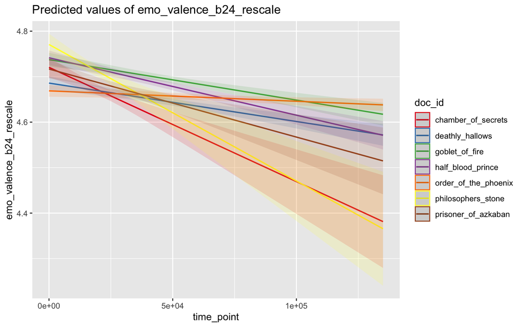

```r
plot_model(og_hp_time_val, type = "int") # visualize
```

```r
fanfic_hp_analysis <- hp_analysis %>% subset(genre == "fanfic")
fanfic_hp_time_val <- lm(emo_valence_b24_rescale ~ time_point*doc_id + word_count, data = fanfic_hp_analysis) #running lmers to test hypotheses
summary(fanfic_hp_time_val) #printing results
```

```
##
## Call:
## lm(formula = emo_valence_b24_rescale ~ time_point * doc_id +
##     word_count, data = fanfic_hp_analysis)
##
## Residuals:
##     Min      1Q  Median      3Q     Max
## -4.8427 -0.2729 -0.1991  0.0015  4.4753
##
## Coefficients: (1 not defined because of singularities)
##                                                    Estimate Std. Error  t value
## (Intercept)                                       4.858e+00  3.726e-03 1303.977
## time_point                                       -1.811e-07  1.409e-08  -12.860
## doc_idAll_the_Young_Dudes_sirius.txt             -8.226e-02  5.645e-03  -14.571
## doc_idAll_the_Young_Dudes.txt                    -8.096e-02  5.903e-03  -13.715
## doc_idAmor_Vincit_Omnia.txt                      -9.563e-02  7.444e-03  -12.847
## doc_idBloody_Slutty.txt                          -2.621e-01  8.732e-03  -30.020
## doc_idcadence_parttime_poets.txt                 -1.055e-01  5.122e-03  -20.590
## doc_idChoices.txt                                -1.821e-01  5.648e-03  -32.233
## doc_idDisappearances_of_draco.txt                -1.752e-01  7.419e-03  -23.623
## doc_idDraco_Malfoy_mortifying.txt                -8.982e-02  8.525e-03  -10.535
## doc_idEvitative.txt                              -1.241e-01  8.142e-03  -15.236
## doc_idHarry_Potter_shadowed_light.txt            -2.759e-02  7.062e-03   -3.907
## doc_idIsolation.txt                              -2.635e-01  7.716e-03  -34.145
## doc_idKill_Your_Darlings.txt                     -1.498e-01  7.090e-03  -21.135
## doc_idLilys_Boy.txt                              -8.566e-02  5.431e-03  -15.774
## doc_idManacled.txt                               -3.357e-01  6.825e-03  -49.193
## doc_idMeasure_Of_A_Man.txt                       -5.185e-02  5.904e-03   -8.782
## doc_idRemain_Nameless.txt                        -9.786e-02  7.155e-03  -13.679
## doc_idThe_Debt_of_Time.txt                       -1.358e-01  5.522e-03  -24.586
## doc_idThe_Right_Thing_To_Do.txt                  -2.843e-02  9.140e-03   -3.111
## doc_idTry_Again.txt                              -1.740e-02  5.818e-03   -2.991
## word_count                                               NA         NA       NA
## time_point:doc_idAll_the_Young_Dudes_sirius.txt  -1.641e-07  2.511e-08   -6.535
## time_point:doc_idAll_the_Young_Dudes.txt          9.720e-08  2.970e-08    3.273
## time_point:doc_idAmor_Vincit_Omnia.txt            3.714e-07  7.424e-08    5.002
## time_point:doc_idBloody_Slutty.txt                1.110e-06  1.349e-07    8.231
## time_point:doc_idcadence_parttime_poets.txt       1.151e-07  1.839e-08    6.261
## time_point:doc_idChoices.txt                      1.663e-07  2.516e-08    6.609
## time_point:doc_idDisappearances_of_draco.txt      3.474e-08  7.328e-08    0.474
```

[output cut: 45 more lines]

```
## time_point:doc_idIsolation.txt                   0.004438 **
## time_point:doc_idKill_Your_Darlings.txt          0.001122 **
## time_point:doc_idLilys_Boy.txt                    < 2e-16 ***
## time_point:doc_idManacled.txt                     < 2e-16 ***
## time_point:doc_idMeasure_Of_A_Man.txt             < 2e-16 ***
## time_point:doc_idRemain_Nameless.txt              < 2e-16 ***
## time_point:doc_idThe_Debt_of_Time.txt             < 2e-16 ***
## time_point:doc_idThe_Right_Thing_To_Do.txt       0.544828
## time_point:doc_idTry_Again.txt                   0.000359 ***
## ---
## Signif. codes:  0 '***' 0.001 '**' 0.01 '*' 0.05 '.' 0.1 ' ' 1
##
## Residual standard error: 1.261 on 4980441 degrees of freedom
## Multiple R-squared:  0.003004,   Adjusted R-squared:  0.002996
## F-statistic: 384.8 on 39 and 4980441 DF,  p-value: < 2.2e-16
```

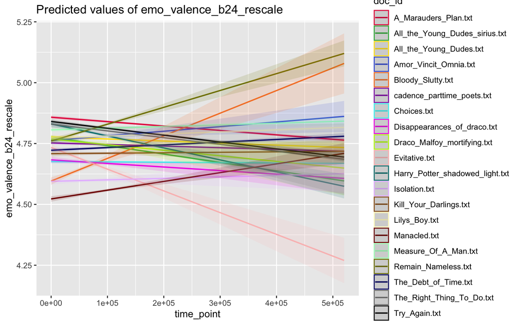

```r
my_colors <- c('#e6194b', '#3cb44b', '#ffe119', '#4363d8', '#f58231', '#911eb4', '#46f0f0', '#f032e6', '#bcf60c', '#fabebe', '#008080', '#e6beff', '#9a6324', '#fffac8', '#800000', '#aaffc3', '#808000', '#000075', '#808080', '#000000')
plot_model(fanfic_hp_time_val, type = "int", colors = my_colors) # visualize
```

## Valence Conclusions

The data suggest that not only is there no overall difference between the original Harry Potter series and it’s fanfiction, but the original series is generally more negative over the course of the story compared to the fanfiction.

BUT this may be less-so due to the original series being “darker” and more-so because the original series tends to start with lighter themes (Opening feast, Christmas chapters, Weasley time) and end with a final battle or conflict. In addition, Fanfiction may simply be more consistently “dark” over time in a way that valence may not be capturing…

# Exploratory Analysis

These additional analyses are supported by my original research question and lit review as well, except rather than using valence to measure the latent variable of “darkness” we are using sadness instead.

## Dataframe Setup (sadness)

```r
hp_clean <- read.csv("hp_clean.csv") #read in cleaned harry potter csv to save on cleaning time (took 24 hours!)

hp_sad_analysis <- hp_clean %>%
  dplyr::left_join(lookup_small, by = c("word_clean" = "word")) %>% #joining gaslighting stories with the sentiment word ratings
  dplyr::select(doc_id, genre, author, word_clean, emo_sadness_rescale) %>% #selecting columns for analysis
  drop_na(emo_sadness_rescale) #dropping empty columns for analysis
hp_sad_analysis[1:20,] #printing the first 20 lines of the df
```

| doc_id | genre | author | word_clean | emo_sadness_rescale |
| --- | --- | --- | --- | --- |
| philosophers_stone | og | 1 | boy | 1.79 |
| philosophers_stone | og | 1 | mrs | 2.50 |
| philosophers_stone | og | 1 | numb | 4.62 |
| philosophers_stone | og | 1 | drive | 1.65 |
| philosophers_stone | og | 1 | proud | 1.43 |
| philosophers_stone | og | 1 | say | 2.60 |
| philosophers_stone | og | 1 | perfectly | 1.98 |
| philosophers_stone | og | 1 | normal | 2.11 |
| philosophers_stone | og | 1 | thank | 1.20 |
| philosophers_stone | og | 1 | very | 2.07 |
| philosophers_stone | og | 1 | much | 2.12 |
| philosophers_stone | og | 1 | last | 3.06 |
| philosophers_stone | og | 1 | people | 2.14 |
| philosophers_stone | og | 1 | expect | 2.86 |
| philosophers_stone | og | 1 | involve | 2.51 |
| philosophers_stone | og | 1 | strange | 1.75 |
| philosophers_stone | og | 1 | mysterious | 2.69 |
| philosophers_stone | og | 1 | just | 1.46 |
| philosophers_stone | og | 1 | hold | 1.67 |
| philosophers_stone | og | 1 | such | 2.35 |

```r
#creating a column to account for differing word counts
hp_sad_analysis <- hp_sad_analysis %>%
  group_by(doc_id) %>%
  mutate(time_point = seq_along(word_clean),
         word_count = n())
hp_sad_analysis[38678:38679,] #printing to make sure its counting correctly
```

```
## # A tibble: 2 × 7
## # Groups:   doc_id [2]
##   doc_id       genre author word_clean emo_sadness_rescale time_point word_count
##   <chr>        <chr>  <int> <chr>                    <dbl>      <int>      <int>
## 1 philosopher… og         1 end                       3.99      38678      38678
## 2 chamber_of_… og         1 bad                       3.76          1      44022
```

```r
hp_sad_analysis[1:20,] #printing the first 20 lines of the df
```

```
## # A tibble: 20 × 7
## # Groups:   doc_id [1]
##    doc_id      genre author word_clean emo_sadness_rescale time_point word_count
##    <chr>       <chr>  <int> <chr>                    <dbl>      <int>      <int>
##  1 philosophe… og         1 boy                       1.79          1      38678
##  2 philosophe… og         1 mrs                       2.50          2      38678
##  3 philosophe… og         1 numb                      4.62          3      38678
##  4 philosophe… og         1 drive                     1.65          4      38678
##  5 philosophe… og         1 proud                     1.43          5      38678
##  6 philosophe… og         1 say                       2.60          6      38678
##  7 philosophe… og         1 perfectly                 1.98          7      38678
##  8 philosophe… og         1 normal                    2.11          8      38678
##  9 philosophe… og         1 thank                     1.20          9      38678
## 10 philosophe… og         1 very                      2.07         10      38678
## 11 philosophe… og         1 much                      2.12         11      38678
## 12 philosophe… og         1 last                      3.06         12      38678
## 13 philosophe… og         1 people                    2.14         13      38678
## 14 philosophe… og         1 expect                    2.86         14      38678
## 15 philosophe… og         1 involve                   2.51         15      38678
## 16 philosophe… og         1 strange                   1.75         16      38678
## 17 philosophe… og         1 mysterious                2.69         17      38678
## 18 philosophe… og         1 just                      1.46         18      38678
## 19 philosophe… og         1 hold                      1.67         19      38678
## 20 philosophe… og         1 such                      2.35         20      38678
```

```r
#making the following variables factors
hp_sad_analysis$doc_id <- as.factor(hp_sad_analysis$doc_id)
hp_sad_analysis$genre <-  as.factor(hp_sad_analysis$genre)
hp_sad_analysis$author <-  as.factor(hp_sad_analysis$author)

#quick summary stats
hp_sad_summary <- hp_sad_analysis %>% group_by(genre) %>% dplyr::summarize_at(c("emo_sadness_rescale"), list(mean=mean, sd=sd, min = min, max = max), na.rm=T) %>% ungroup() #grouping dataframe by gaslighting endorsement to summarize variables
print(hp_sad_summary) #printing results
```

```
## # A tibble: 2 × 5
##   genre   mean    sd   min   max
##   <fct>  <dbl> <dbl> <dbl> <dbl>
## 1 fanfic  2.33 0.767     0     9
## 2 og      2.34 0.741     0     9
```

```r
hp_word_summary <- hp_sad_analysis %>% group_by(genre) %>% dplyr::summarize_at(c("word_count"), list(mean=mean, sd=sd, min = min, max = max), na.rm=T) %>% ungroup() #grouping dataframe by gaslighting endorsement to summarize variables
print(hp_word_summary) #printing results
```

```
## # A tibble: 2 × 5
##   genre     mean      sd   min    max
##   <fct>    <dbl>   <dbl> <int>  <int>
## 1 fanfic 317441. 127577. 94379 519244
## 2 og      91825.  30745. 38678 132657
```

## Overall Sadness

Like its sibling analysis before it, the overall sadness model proves to be null. There is no significant difference in sadness between fanfiction and the original series and there is again a really large confidence interval for the original compared to the fanfiction.

```r
hp_sad <- lmer(emo_sadness_rescale ~ genre + word_count + (1|author) + (1|doc_id), data = hp_sad_analysis) #running lmers to test hypotheses
summary(hp_sad) #printing results
```

```
## Linear mixed model fit by REML. t-tests use Satterthwaite's method [
## lmerModLmerTest]
## Formula: emo_sadness_rescale ~ genre + word_count + (1 | author) + (1 |
##     doc_id)
##    Data: hp_sad_analysis
##
## REML criterion at convergence: 12893317
##
## Scaled residuals:
##     Min      1Q  Median      3Q     Max
## -3.1817 -0.5442  0.0280  0.5274  8.8445
##
## Random effects:
##  Groups   Name        Variance  Std.Dev.
##  doc_id   (Intercept) 0.0001726 0.01314
##  author   (Intercept) 0.0024641 0.04964
##  Residual             0.5824317 0.76317
## Number of obs: 5612208, groups:  doc_id, 27; author, 20
##
## Fixed effects:
##              Estimate Std. Error        df t value Pr(>|t|)
## (Intercept) 2.313e+00  1.989e-02 2.267e+01 116.271   <2e-16 ***
## genreog     1.971e-02  5.244e-02 1.410e+01   0.376    0.713
## word_count  6.845e-08  6.346e-08 1.515e+01   1.079    0.298
## ---
## Signif. codes:  0 '***' 0.001 '**' 0.01 '*' 0.05 '.' 0.1 ' ' 1
##
## Correlation of Fixed Effects:
##            (Intr) genreg
## genreog    -0.302
## word_count -0.806  0.210
## fit warnings:
## Some predictor variables are on very different scales: consider rescaling.
## You may also use (g)lmerControl(autoscale = TRUE) to improve numerical stability.
```

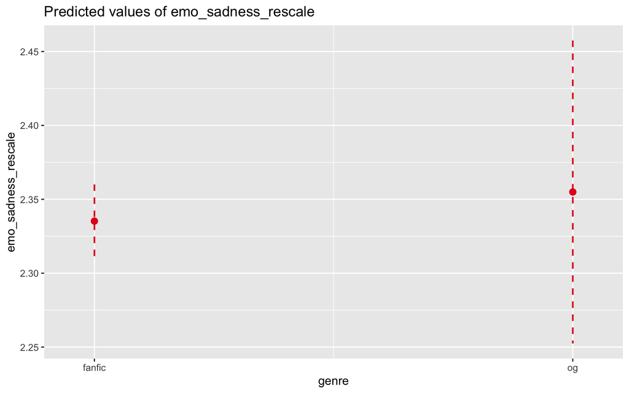

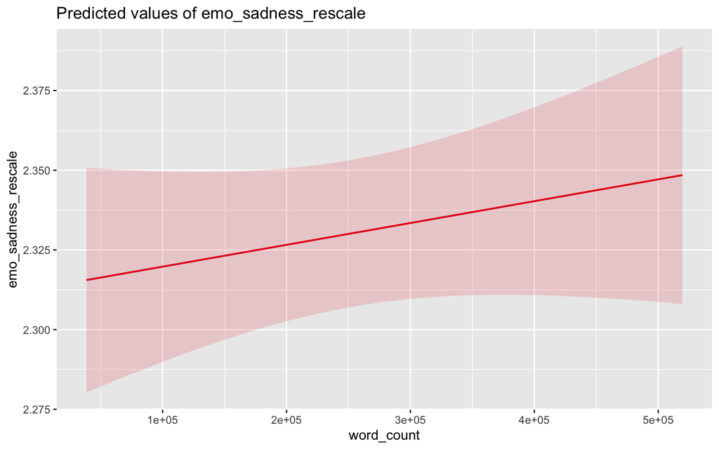

```r
#vizualize
plot_model(hp_sad, type = "pred")
```

## Sadness Over Time

Tragically, the results are identical to the valence results but flipped because on the scale of sadness higher scores indicate more sadness.

```r
hp_time_sad <- lmer(emo_sadness_rescale ~ time_point*genre + word_count + (1|author) + (1|doc_id), data = hp_sad_analysis) #running lmers to test hypotheses
summary(hp_time_sad) #printing results
```

```
## Linear mixed model fit by REML. t-tests use Satterthwaite's method [
## lmerModLmerTest]
## Formula: emo_sadness_rescale ~ time_point * genre + word_count + (1 |
##     author) + (1 | doc_id)
##    Data: hp_sad_analysis
##
## REML criterion at convergence: 12892999
##
## Scaled residuals:
##     Min      1Q  Median      3Q     Max
## -3.1784 -0.5448  0.0271  0.5272  8.8509
##
## Random effects:
##  Groups   Name        Variance  Std.Dev.
##  doc_id   (Intercept) 0.0002117 0.01455
##  author   (Intercept) 0.0022285 0.04721
##  Residual             0.5823917 0.76315
## Number of obs: 5612208, groups:  doc_id, 27; author, 20
##
## Fixed effects:
##                      Estimate Std. Error         df t value Pr(>|t|)
## (Intercept)         2.327e+00  2.003e-02  2.375e+01 116.173   <2e-16 ***
## time_point          3.541e-08  3.435e-09  5.585e+06  10.310   <2e-16 ***
## genreog            -1.326e-02  5.020e-02  1.512e+01  -0.264    0.795
## word_count         -6.814e-09  6.543e-08  1.993e+01  -0.104    0.918
## time_point:genreog  5.788e-07  3.675e-08  8.074e+04  15.752   <2e-16 ***
## ---
## Signif. codes:  0 '***' 0.001 '**' 0.01 '*' 0.05 '.' 0.1 ' ' 1
##
## Correlation of Fixed Effects:
##             (Intr) tm_pnt genreg wrd_cn
## time_point  -0.003
## genreog     -0.315  0.004
## word_count  -0.825 -0.023  0.227
## tm_pnt:gnrg  0.032 -0.093 -0.038 -0.037
## fit warnings:
## Some predictor variables are on very different scales: consider rescaling.
## You may also use (g)lmerControl(autoscale = TRUE) to improve numerical stability.
```

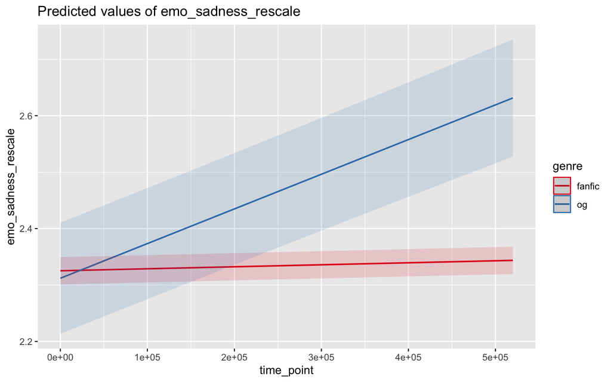

```r
# visualize
plot_model(hp_time_sad, type = "int")
```

```r
og_hp_sad_analysis <- hp_sad_analysis %>% subset(genre == "og")
og_hp_time_val <- lm(emo_sadness_rescale ~ time_point*doc_id + word_count, data = og_hp_sad_analysis) #running lmers to test hypotheses
summary(og_hp_time_val) #printing results
```

```
##
## Call:
## lm(formula = emo_sadness_rescale ~ time_point * doc_id + word_count,
##     data = og_hp_sad_analysis)
##
## Residuals:
##     Min      1Q  Median      3Q     Max
## -2.3557 -0.4039  0.0167  0.3670  6.6724
##
## Coefficients: (1 not defined because of singularities)
##                                         Estimate Std. Error t value Pr(>|t|)
## (Intercept)                            2.299e+00  7.057e-03 325.739  < 2e-16
## time_point                             1.606e-06  2.777e-07   5.783 7.36e-09
## doc_iddeathly_hallows                  2.702e-02  8.483e-03   3.185 0.001448
## doc_idgoblet_of_fire                  -6.970e-03  8.500e-03  -0.820 0.412230
## doc_idhalf_blood_prince                5.208e-03  8.674e-03   0.600 0.548249
## doc_idorder_of_the_phoenix             1.920e-02  8.145e-03   2.358 0.018380
## doc_idphilosophers_stone              -1.393e-02  1.032e-02  -1.350 0.177007
## doc_idprisoner_of_azkaban              1.706e-02  9.537e-03   1.789 0.073684
## word_count                                    NA         NA      NA       NA
## time_point:doc_iddeathly_hallows      -9.530e-07  2.896e-07  -3.290 0.001001
## time_point:doc_idgoblet_of_fire       -9.617e-07  2.901e-07  -3.315 0.000916
## time_point:doc_idhalf_blood_prince    -8.266e-07  2.956e-07  -2.797 0.005165
## time_point:doc_idorder_of_the_phoenix -1.153e-06  2.827e-07  -4.079 4.52e-05
## time_point:doc_idphilosophers_stone    2.183e-07  4.368e-07   0.500 0.617200
## time_point:doc_idprisoner_of_azkaban  -5.625e-07  3.473e-07  -1.620 0.105299
##
## (Intercept)                           ***
## time_point                            ***
## doc_iddeathly_hallows                 **
## doc_idgoblet_of_fire
## doc_idhalf_blood_prince
## doc_idorder_of_the_phoenix            *
## doc_idphilosophers_stone
## doc_idprisoner_of_azkaban             .
## word_count
## time_point:doc_iddeathly_hallows      **
## time_point:doc_idgoblet_of_fire       ***
## time_point:doc_idhalf_blood_prince    **
## time_point:doc_idorder_of_the_phoenix ***
## time_point:doc_idphilosophers_stone
## time_point:doc_idprisoner_of_azkaban
## ---
## Signif. codes:  0 '***' 0.001 '**' 0.01 '*' 0.05 '.' 0.1 ' ' 1
##
## Residual standard error: 0.7404 on 551502 degrees of freedom
## Multiple R-squared:  0.0009027,  Adjusted R-squared:  0.0008792
## F-statistic: 38.33 on 13 and 551502 DF,  p-value: < 2.2e-16
```

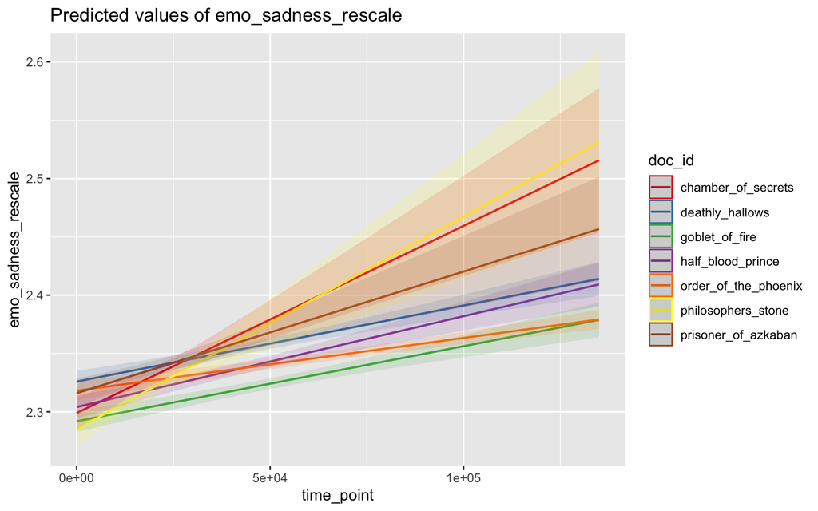

```r
plot_model(og_hp_time_val, type = "int") # visualize
```

```r
fanfic_hp_sad_analysis <- hp_sad_analysis %>% subset(genre == "fanfic")
fanfic_hp_time_val <- lm(emo_sadness_rescale ~ time_point*doc_id + word_count, data = fanfic_hp_sad_analysis) #running lmers to test hypotheses
summary(fanfic_hp_time_val) #printing results
```

```
##
## Call:
## lm(formula = emo_sadness_rescale ~ time_point * doc_id + word_count,
##     data = fanfic_hp_sad_analysis)
##
## Residuals:
##     Min      1Q  Median      3Q     Max
## -2.4279 -0.4150  0.0211  0.4064  6.7809
##
## Coefficients: (1 not defined because of singularities)
##                                                    Estimate Std. Error t value
## (Intercept)                                       2.252e+00  2.256e-03 998.162
## time_point                                        1.152e-07  8.489e-09  13.572
## doc_idAll_the_Young_Dudes_sirius.txt              9.665e-02  3.407e-03  28.367
## doc_idAll_the_Young_Dudes.txt                     9.697e-02  3.567e-03  27.188
## doc_idAmor_Vincit_Omnia.txt                       6.899e-02  4.459e-03  15.474
## doc_idBloody_Slutty.txt                           1.250e-01  5.208e-03  24.002
## doc_idcadence_parttime_poets.txt                  8.973e-02  3.099e-03  28.952
## doc_idChoices.txt                                 1.253e-01  3.427e-03  36.576
## doc_idDisappearances_of_draco.txt                 1.242e-01  4.439e-03  27.971
## doc_idDraco_Malfoy_mortifying.txt                 4.631e-02  5.162e-03   8.971
## doc_idEvitative.txt                               5.786e-02  4.855e-03  11.918
## doc_idHarry_Potter_shadowed_light.txt            -3.716e-02  4.256e-03  -8.731
## doc_idIsolation.txt                               1.514e-01  4.679e-03  32.351
## doc_idKill_Your_Darlings.txt                      8.832e-02  4.312e-03  20.483
## doc_idLilys_Boy.txt                               4.522e-02  3.264e-03  13.854
## doc_idManacled.txt                                1.755e-01  4.098e-03  42.826
## doc_idMeasure_Of_A_Man.txt                        3.155e-02  3.567e-03   8.844
## doc_idRemain_Nameless.txt                         6.611e-02  4.300e-03  15.374
## doc_idThe_Debt_of_Time.txt                        1.016e-01  3.349e-03  30.345
## doc_idThe_Right_Thing_To_Do.txt                   1.937e-02  5.471e-03   3.540
## doc_idTry_Again.txt                              -1.614e-02  3.503e-03  -4.609
## word_count                                               NA         NA      NA
## time_point:doc_idAll_the_Young_Dudes_sirius.txt   4.142e-08  1.494e-08   2.772
## time_point:doc_idAll_the_Young_Dudes.txt         -7.740e-08  1.774e-08  -4.363
## time_point:doc_idAmor_Vincit_Omnia.txt           -3.459e-07  4.287e-08  -8.069
## time_point:doc_idBloody_Slutty.txt               -3.880e-07  7.687e-08  -5.047
## time_point:doc_idcadence_parttime_poets.txt      -1.190e-07  1.106e-08 -10.761
## time_point:doc_idChoices.txt                     -7.797e-08  1.525e-08  -5.112
## time_point:doc_idDisappearances_of_draco.txt     -4.685e-08  4.215e-08  -1.111
```

[output cut: 45 more lines]

```
## time_point:doc_idIsolation.txt                   0.001126 **
## time_point:doc_idKill_Your_Darlings.txt          0.911636
## time_point:doc_idLilys_Boy.txt                    < 2e-16 ***
## time_point:doc_idManacled.txt                    0.000351 ***
## time_point:doc_idMeasure_Of_A_Man.txt            1.11e-06 ***
## time_point:doc_idRemain_Nameless.txt              < 2e-16 ***
## time_point:doc_idThe_Debt_of_Time.txt             < 2e-16 ***
## time_point:doc_idThe_Right_Thing_To_Do.txt       0.943955
## time_point:doc_idTry_Again.txt                   0.073752 .
## ---
## Signif. codes:  0 '***' 0.001 '**' 0.01 '*' 0.05 '.' 0.1 ' ' 1
##
## Residual standard error: 0.7655 on 5060652 degrees of freedom
## Multiple R-squared:  0.003852,   Adjusted R-squared:  0.003844
## F-statistic: 501.7 on 39 and 5060652 DF,  p-value: < 2.2e-16
```

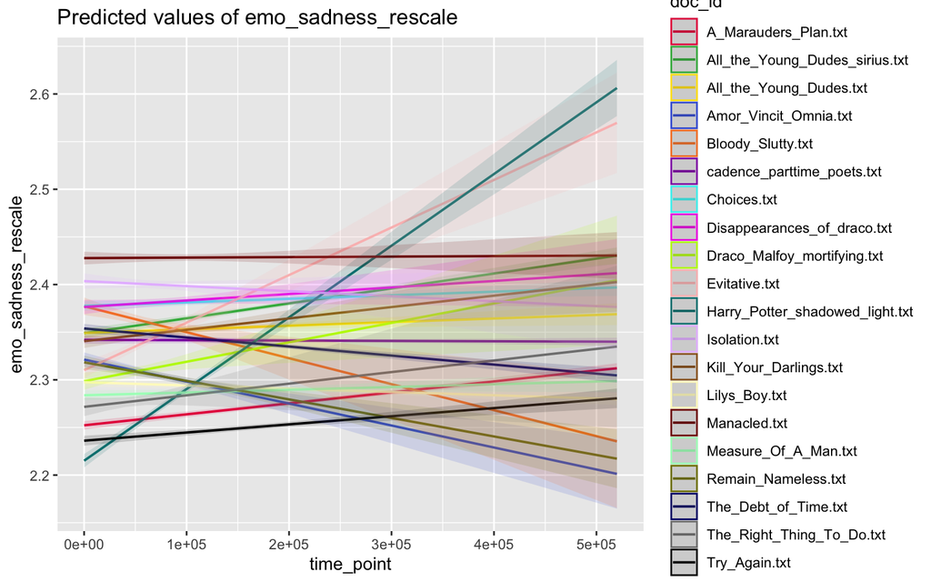

```r
my_colors <- c('#e6194b', '#3cb44b', '#ffe119', '#4363d8', '#f58231', '#911eb4', '#46f0f0', '#f032e6', '#bcf60c', '#fabebe', '#008080', '#e6beff', '#9a6324', '#fffac8', '#800000', '#aaffc3', '#808000', '#000075', '#808080', '#000000')
plot_model(fanfic_hp_time_val, type = "int", colors = my_colors) # visualize
```

# Overall Conclusions

My final thoughts based on this analysis are that it looks like fanfiction as a whole is NOT particularly darker than its source material. In fact it seems like they generally maintain the same valence and sadness overtime not moving much throughout the story save for a few outliers.

There are some limitations to my analyses of course: 1. Data cleaning was messy and many words that got smooshed together ended up needing to be dropped 2. The analyses assume linearity in storytelling (not accounting for individual high-highs and low-lows) 3. And perhaps my biggest concern, which is that valence database does not take context into account

Future directions might include semantic embedding analyses and may attempt to select a sample of fanfiction tagged specifically for their more negatively valenced content to better analyze this question and to serve as a proof of concept. In addition, running a smaller dataset analysis comparing a smaller group of fanfictions to the books would likely make these analyses easier to interpret.